# Pivoting Exercise

Load the tidyverse package, this contains ggplot and dplyr so no need to load those in alongside it.

```r
library(tidyverse)
```

# Pivoting Longer

Copy this dataframe into your r session:

```r
revenue <- data.frame(
  cid = c(1, 2, 3),
  customers = c("Odile", "Rasheda", "Ettie"),
  age = c(7, 2, 25),
  revenue.2016 = c(272, 478, 614),
  revenue.2017 = c(345, 788, 655),
  revenue.2018 = c(495, 390, 702)
)
```

If we were wanting to plot revenue for each customer we would have to create 3 separate plots in this format.

Using the pivot_longer function we can make a new column that is “year” which encompasses the 2016, 2017, and 2018 columns.

```r
revenue_long <- revenue %>%
  pivot_longer(cols = starts_with("revenue"),
               names_to = "year",
               values_to = "revenue")

print(revenue_long)
```

```
## # A tibble: 9 × 5
##     cid customers   age year         revenue
##   <dbl> <chr>     <dbl> <chr>          <dbl>
## 1     1 Odile         7 revenue.2016     272
## 2     1 Odile         7 revenue.2017     345
## 3     1 Odile         7 revenue.2018     495
## 4     2 Rasheda       2 revenue.2016     478
## 5     2 Rasheda       2 revenue.2017     788
## 6     2 Rasheda       2 revenue.2018     390
## 7     3 Ettie        25 revenue.2016     614
## 8     3 Ettie        25 revenue.2017     655
## 9     3 Ettie        25 revenue.2018     702
```

Now we can create better plots with this format!

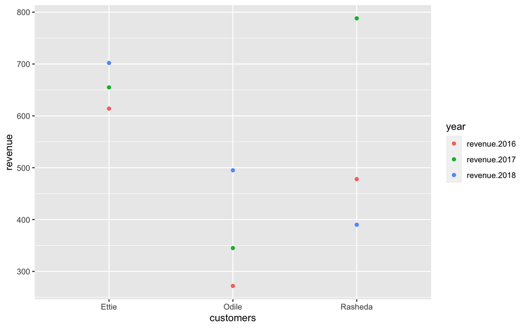

```r
revenue_long %>%
  ggplot(aes(x=customers,y=revenue,color=year)) +
  geom_point()
```

We can also use the facet_wrap function if we wanted to create 3 separate plots

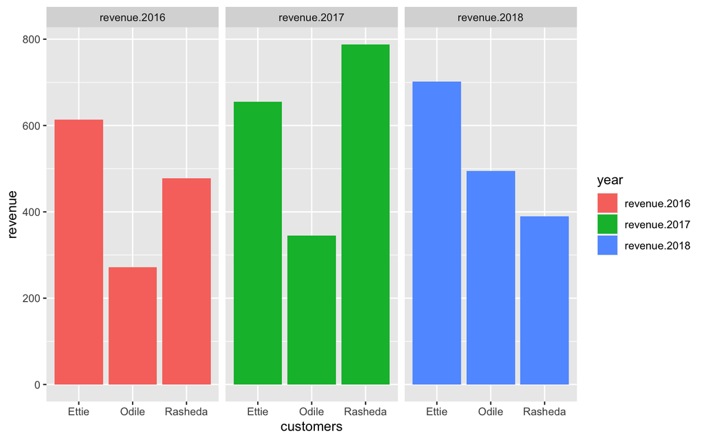

```r
revenue_long %>%
  ggplot(aes(x=customers,y=revenue,fill = year)) +
  geom_col() +
  facet_wrap(~year)
```

Facet_wrap created individual plots based on the variable you give it, in this case it separted into 3 plots since the ~year column has three unique values.

## Pivoting Longer Exercise

Look at the billboard dataframe from the tidyverse package.

This dataframe contains tracks and their rank on the top 100. It has weeks in individual columns. Each week is showing the rank of that song from the first week it got on the top 100 chart.

Try to recreate this plot:

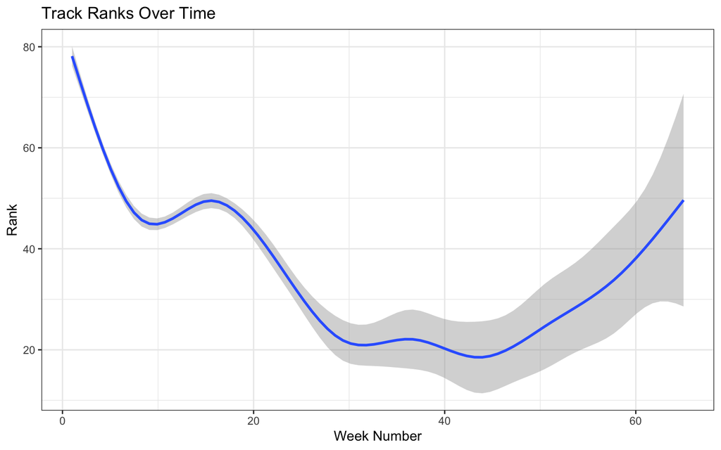

## Hints:

- When pivoting longer you can use the **cols = starts_with()** function to specify which columns you want to select based on what character they start with.
- Make sure the new “week” column in numeric (you’ll need to remove the “wk” from the observations first).
- geom_smooth() is the ggplot function to plot a curve representing the relationship between variables.
- Change labels in ggplot with labs function: **+ labs(title = , x = , y = )**

# Pivot Wider

Copy this dataframe into your r session:

```r
life_df <- data.frame(
  country = c("Brazil", "Brazil", "Brazil", "China", "China", "China", "United States", "United States", "United States"),
  continent = c("Americas", "Americas", "Americas", "Asia", "Asia", "Asia", "Americas", "Americas", "Americas"),
  year = c(1952, 1977, 2007, 1952, 1977, 2007, 1952, 1977, 2007),
  lifeExp = c(50.9, 61.5, 72.4, 44, 64.0, 73.0, 68.4, 73.4, 78.2)
)
```

Looking at this dataframe it is showing the life expectancy for Brazil, China and the United States in the years 1952, 1977 and 2007.

```r
print(life_df)
```

```
##         country continent year lifeExp
## 1        Brazil  Americas 1952    50.9
## 2        Brazil  Americas 1977    61.5
## 3        Brazil  Americas 2007    72.4
## 4         China      Asia 1952    44.0
## 5         China      Asia 1977    64.0
## 6         China      Asia 2007    73.0
## 7 United States  Americas 1952    68.4
## 8 United States  Americas 1977    73.4
## 9 United States  Americas 2007    78.2
```

If you wanted the table easier to view life expectancy in the table you could use the **pivot wider** function. Pivoting wider works by creating new columns based on the observations in a column and using values from a different column to fill in the rows.

```r
life_df_wide <- life_df %>% pivot_wider(names_from = "year",
                        values_from = "lifeExp")
```

[output not shown]

## Pivoting Wider Exercise

Load in the us_rent_income dataframe from the tidyverse package

Create this plot (no pivoting necessary)

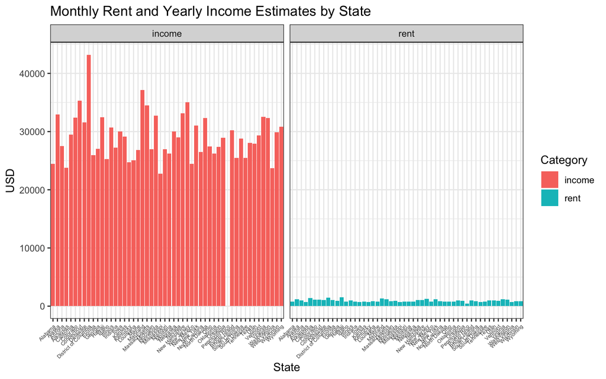

This plot shows interesting information, but what if you wanted the rent to be displayed as yearly? This would give a better look at the cost percentage of rent compared to income.

Try to make this plot:

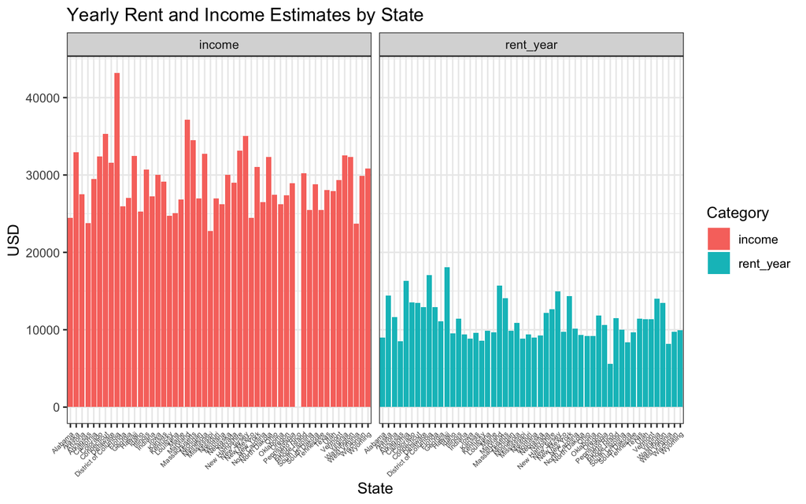

## Hints:

- Start by removing the “moe” column, this makes the next steps much easier
- Pivot wider so you have new columns “income” and “rent”
- Create new column that is the rent cost for a year (multiply rent column by 12)
- Pivot longer to bring the dataframe back into a long format (this is the better format for plotting)
- To set x-axis text at an angle in ggplot: **+ theme(axis.text.x = element_text(angle = 45, hjust = 1, size = 5))**